# Title: Reproducible Research: Peer Assessment 1: Submission

## output: PA1_Template.html

This is an R Markdown document used for the class Reproducible Research: Peer Assessment 1.

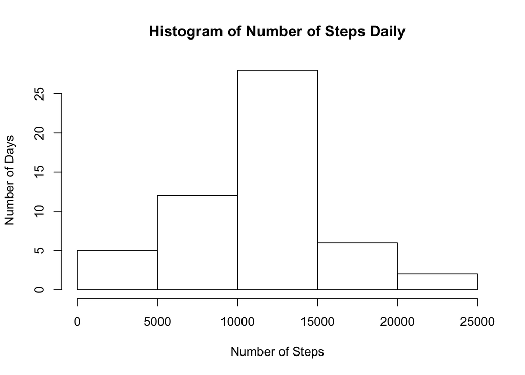

```r
data <- read.csv("activity.csv")
dailyStepData <- aggregate(data$steps, list(data$date), sum)
colnames(dailyStepData) <- c("Dates", "Steps")
hist(dailyStepData$Steps, xlab = "Number of Steps", ylab = "Number of Days", main = "Histogram of Number of Steps Daily")
```

```r
mean(dailyStepData$Steps, na.rm = TRUE)
```

```
## [1] 10766.19
```

```r
median(dailyStepData$Steps, na.rm = TRUE)
```

```
## [1] 10765
```

**Daily Pattern Activity Code**

This code describes the average number of steps every five minutes and tells which interval has the maximum number of steps.

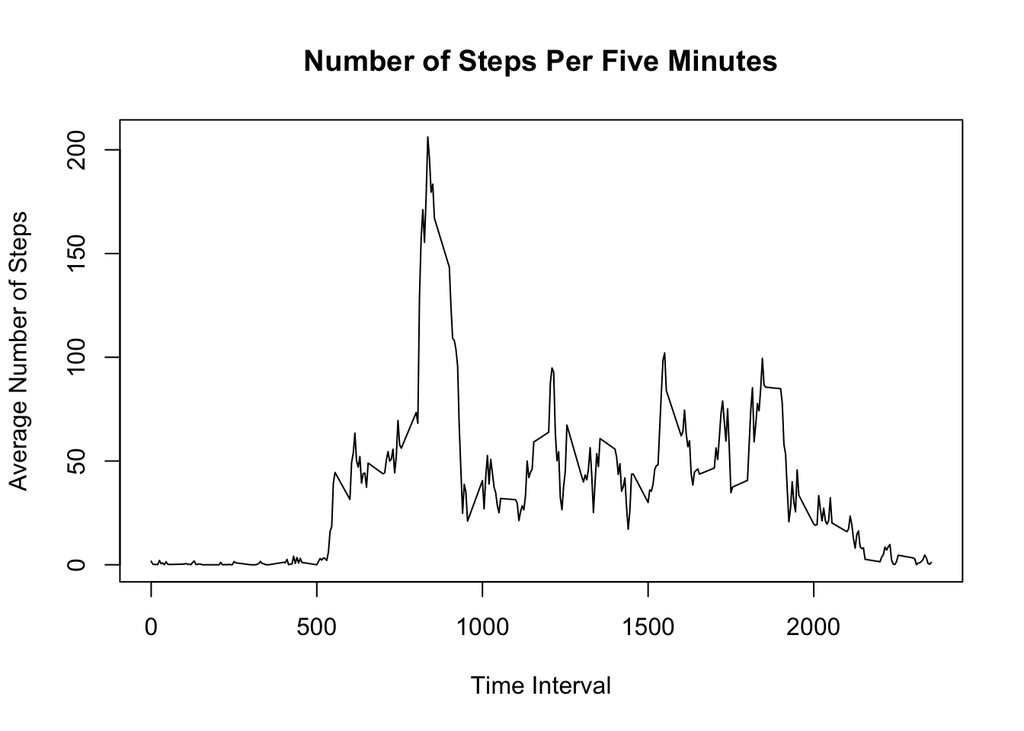

```r
intervalStepData <- aggregate(data$steps, list(data$interval), FUN=mean, na.rm = TRUE)
colnames(intervalStepData) <- c("interval", "stepAverage")
plot(intervalStepData, type = 'l', xlab = "Time Interval", ylab = "Average Number of Steps", main = "Number of Steps Per Five Minutes")
```

```r
maxSteps = intervalStepData$stepAverage == max(intervalStepData$stepAverage)
intervalStepData[maxSteps == TRUE,]
```

```
##     interval stepAverage
## 104      835    206.1698
```

**Inputting Missing Values Code**

The number of cases that have NA values:

```r
completeCasesVector <- complete.cases(data)
length(completeCasesVector[completeCasesVector == FALSE])
```

```
## [1] 2304
```

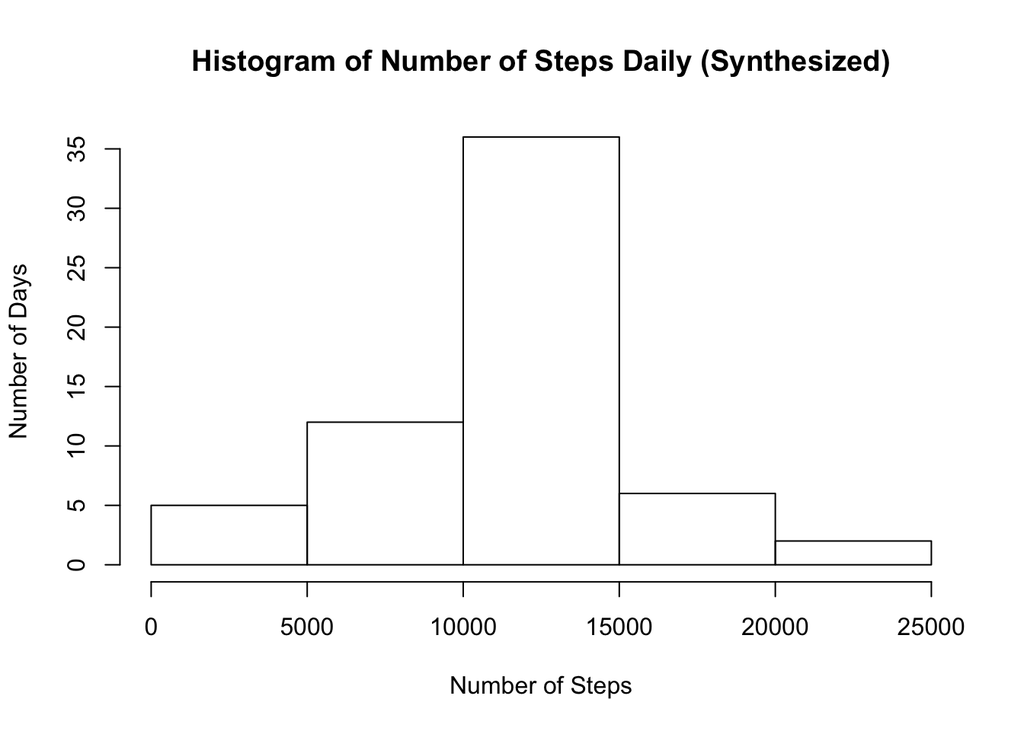

```r
missingDataSet <- data
for(i in 1:nrow(missingDataSet)){

  if(completeCasesVector[i] == FALSE)
  {
    intervalVariable = missingDataSet[i, 3]
    ivsOne = intervalStepData[intervalStepData$interval == intervalVariable,][2]
    missingDataSet[i, 1] = ivsOne
  }

}

dailyFilledInStepData <- aggregate(missingDataSet$steps, list(missingDataSet$date), sum)
colnames(dailyFilledInStepData) <- c("Dates", "Steps")
hist(dailyFilledInStepData$Steps, xlab = "Number of Steps", ylab = "Number of Days", main = "Histogram of Number of Steps Daily (Synthesized)")
```

```r
mean(dailyFilledInStepData$Steps)
```

```
## [1] 10766.19
```

```r
median(dailyFilledInStepData$Steps)
```

```
## [1] 10766.19
```

Conclusions:

The shape of each histogram is the same, approximately normal, and while the means are the same (using the interval replacement method) the medians differ slightly (10765 on the original data set versus 10766.19 on the data set with synthesized values). This should be expected as the number of values is increased on the second data set but slightly and therefore the median should also change (assuming the NA values are ignored in the original calculation of the median on the original data set). It should also be noted that on the sythesized data set the number of days (the frequency) is slightly higher with the max frequency reaching approximately 35 while on the original dataset the maximum frequency was approximately 25. This would make sense as the substitute values should increase the number of days with valid values thereby increasing the height of the some values in the histogram.

**Weekend vs. Weekday Analysis**

This section describes the average number of steps taken every five minutes on weekdays versus weekends.

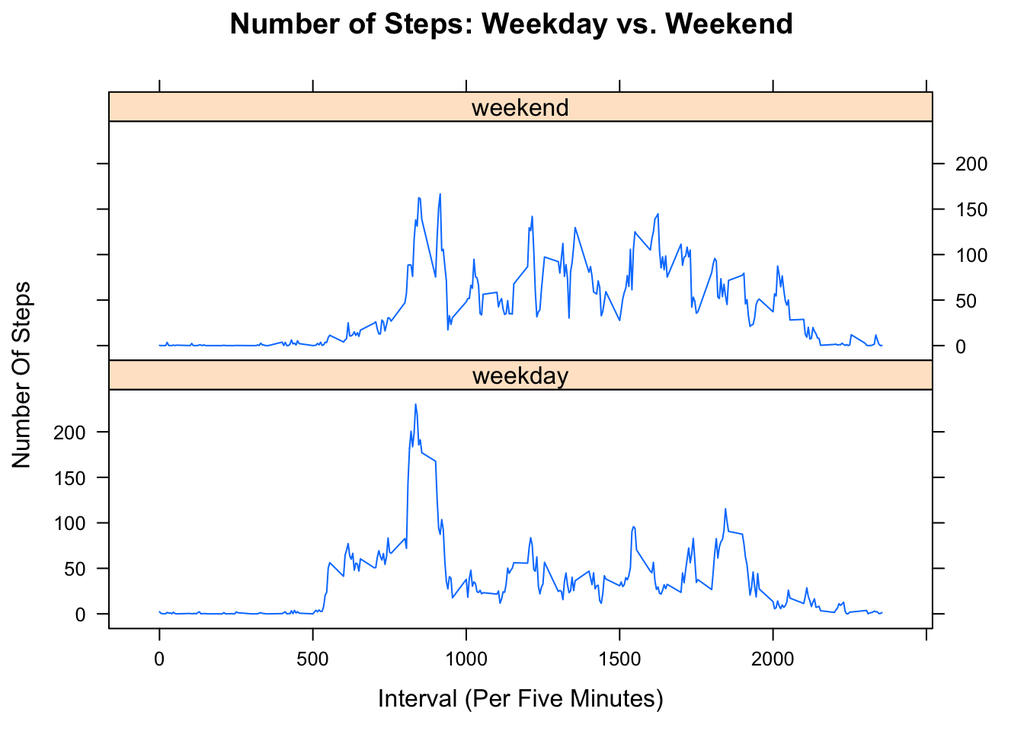

```r
missingDataSetWithWeekend <- missingDataSet
missingDataSetWithWeekend$WeekDay <- ifelse((as.POSIXlt(missingDataSetWithWeekend$date)$wday == 6 | as.POSIXlt(missingDataSetWithWeekend$date)$wday == 0), "weekend", "weekday" )
missingDataSetWithWeekend$WeekDay = as.factor(missingDataSetWithWeekend$WeekDay)
aggMissingDataSetWithWeekend <- aggregate(missingDataSetWithWeekend$steps, list(missingDataSetWithWeekend$WeekDay, missingDataSetWithWeekend$interval), FUN=mean, na.rm = TRUE)
colnames(aggMissingDataSetWithWeekend) <- c("weekend", "interval", "steps")

intervalStepData <- aggregate(data$steps, list(data$interval), FUN=mean, na.rm = TRUE)
dailyFilledInStepData <- aggregate(missingDataSet$steps, list(missingDataSet$date), sum)
colnames(dailyFilledInStepData) <- c("Dates", "Steps")

library(lattice)

xyplot(steps~interval|weekend,  data = aggMissingDataSetWithWeekend,
       main="Number of Steps: Weekday vs. Weekend", layout = c(1, 2),
       ylab="Number Of Steps", xlab="Interval (Per Five Minutes)", type = "l")
```

```r
mean(aggMissingDataSetWithWeekend$steps)
```

```
## [1] 38.98849
```

```r
median(aggMissingDataSetWithWeekend$steps)
```

```
## [1] 28.13325
```